# 102A Hw5

Seulchan Kim

2019 2 27

*Modify this file with your answers and responses. Please preserve all text that is italicized.*

*You are encouraged to collaborate with your classmates, however, you are responsible for your own work. Please do not ask people outside of this class for help with this assignment.*

1. **Read**
   1. SPURS:
      - Chapter 9
      - Chapter 10
      - Chapter 12 sections 1-2
2. **An IEEE 754 Mini-Floating Point number [20 points, 2pts each part]**_

In class, I demonstrated the use of a mini-floating point number system using 8 bits. In my class demo, I used 1 bit for the sign, 3 bits for the exponent, and 4 bits for the mantissa. For this problem, imagine I had used 10 bits - 1 bit for the sign, 4 bits for the exponent, and 5 bits for the mantissa.

```c
0 0000 00000 # would now represent the decimal value 0
```

Answer the following questions under this new system.

1. **What is the bias that would be used for the exponent? What is the largest positive exponent? What is the most negative exponent?**

bias is 2^(4-1)-1 = 7. The largest exponenet is 14-7 = 7, 1110 with bias of 7 in binary. The most negative exponenet, it would be 0001 or 0000 (denormalized case). Anyway both cases show the same results since denomalized value’s bias is 1 less than usual. Therefore, the most negative exponenet is 0 -6 = 1 - 7 = -6.

2. **How would the value 5.5 be stored in this system?**

Since the 5.5 is a positive number, the first digit should be 0. 5.5 can be expressed as 101.1 in binary expression, and it is 1.011 * 2^2. The exponent is biased by 7 so for exponenet, the result is 1001. And the Mantissa would be 01100 in order to express 1.011 * 2^2

The final result is : 0 | 1001 | 01100.

3. **What value would the following bit sequence represent `0 0111 00000`?**

First digit is 0 and it means positive. Exponent digit = 0111 which means 2^2 + 2^1 + 2^0 = 7. In addition, Mantissa digit = 00000 would lead to â+1.00000 * 2^(7-7)â. 1.00000 * 1 = 1 => 2^0 = 1. So the answer is 1

4. **What value would the following bit sequence represent `0 0111 00001`? (Express as a fraction and also in decimal.)**

First digit is 0 and it means positive. Exponent digit = 0111 which means 2^2 + 2^1 + 2^0 = 7. In addition, Mantissa digit = 00001 would lead to “+1.00001 * 2^(7-7)â” 1.00001 * 1 = 1.00001 => 2^0 + 2^(-5) = 1 + 1/32 = 33/32 So the answer is 33/32 in fraction, and 1.03125 in decimal.

5. **What is the smallest positive normalized value that can be expressed? (Fill in the bits. Express as a fraction and also in decimal.)**

0 0001 00000. It is +1.00000 * 2^(1-7) = 2(-6) So the smallest positive normalized value is (1/64) in fraction, and (0.015625) in decimal.

6. **What is the smallest positive (denormalized) non-zero value that can be expressed? (Fill in the bits. Express as a fraction and also in decimal.)**

0 0000 00001. It is +0.00001 * 2^(0-6), since it is denormalized value, our bias is 7-1 = 6. So the smallest positive denormalized value is (1/2048) in fraction, and (0.00048828125) in decimal.

7. **What is the largest denormalized value that can be expressed? (Fill in the bits. Express as a fraction and also in decimal.)**

0 0000 11111. It is +0.11111 * 2^(0-6), since it is denormalized value, our bias is 7-1 = 6. It means 2(-7)+2(-8)+2(-9)+2(-10)+2^(-11) = 31/2048. So the largest positive denormalized value is (31/2048) in fraction, and (0.01513671875) in decimal.

8. **What is the largest finite value that can be expressed with this sytem? (Fill in the bits. Express as a fraction and also in decimal.)**

answer 0 1110 11111 If we have all 1â’s in exponent digits, it becomes infinity. Therefore we need to leave the last digit as 0. It means +1.11111 * 2^(14-7) = 1111100 in binary, which means 27+26+25+24+23+22. So the largest finite value that can be expressed with this system (252/1) = 252.

1. **The machine epsilon is the size of the smallest increment that we can differentiate between two adjacent values in the mantissa (regardless of the exponent). Values with a difference smaller than machine epsilon are seen as equivalent in floating point. For our system, it is equivalent to the difference between your answer to parts c and d above: 1/32. If you ask R for `.Machine$double.eps`, you get 2.220446e-16. What power of 2 is that equal to?**

2x = 2.220446e-16

=> x = log22.220446e-16 = - 52.00000003199951 approximately equal to - 52

2^(-52)

10. **With our 10 bit floating point system, the machine epsilon is 1/32. What will the following return? (Hint: can you represent the left-hand side with a sequence of bits that is different from the right-hand side?).**

(1 + 1/64) == 1 [1] TRUE

(1 - 1/64) == 1 [1] FALSE

3. **Root Finding with Fixed Point Iteration [12 points, 2 points each part]**

This is a modified version of SPURS chapter 10, section 6, exercise 4.

I have written my own version of fixedpoint_show, which uses ggplot to produce the graphs. The code performs fixed point iteration to find a solution to $f(x) = x$.

I have modified it so that it works better for R Markdown output. Instead of prompting the user to continue, it will perform a number of iterations as specified by the `iter` value in the parameters. I encourage you to read through the code line by line and make sure you understand it.

- Do part (a) using x0 = 1
- Do part (a) using x0 = 3
- Do part (a) using x0 = 6
- Do part (b) using x0 = 2
- Do part (c) using x0 = 2
- Do part (d) using x0 = 2, no more than 6 iterations

**note that parts b, c, d are all ways of rewriting f(x) = log(x) - exp(-x) = 0 as g(x) = x**

```
## Starting value is: 1
## Next value of x is: 0.5403023
## Next value of x is: 0.8575532
## Next value of x is: 0.6542898
## Next value of x is: 0.7934804
## Next value of x is: 0.7013688
## Next value of x is: 0.7639597
## Next value of x is: 0.7221024
## Next value of x is: 0.7504178
## Next value of x is: 0.731404
## Next value of x is: 0.7442374
```

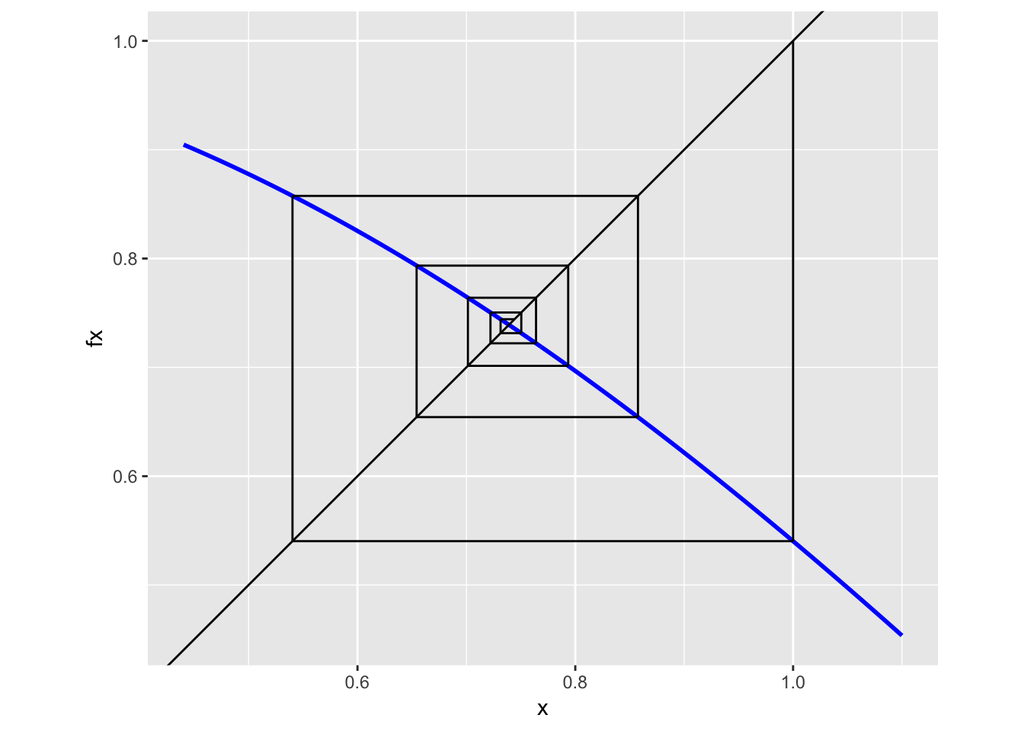

```
## [1] 0.7442374
```

```r
library(ggplot2)
fixedpoint_show <- function(ftn, x0, iter = 5){
  # applies fixed-point method to find x such that ftn(x) = x
  # ftn is a user-defined function

  # df_points is used to track each update
  # it will be used to plot the line segments showing each update
  # each line segment connects the points (x1,y1) to (x2,y2)
  df_points <- data.frame(x1=numeric(0),y1=numeric(0),x2=numeric(0),y2=numeric(0))

  xnew <- x0
  cat("Starting value is:", xnew, "\n")

  # iterate the fixed point algorithm
  for(i in 1:iter){
    xold <- xnew
    xnew <- ftn(xold)
    cat("Next value of x is:", xnew, "\n")

    df_points[2*i-1,] <- c(xold, xold, xold, xnew) # vertical (x1 = x2)
    df_points[2*i,] <- c(xold, xnew, xnew, xnew) # horizontal (y1 = y2)
  }

  ### use ggplot to plot the function and the segments for each iteration
  # determine the limits to use for the plot
  plot_start <- min(df_points$x1, df_points$x2, x0) - 0.1  # start is the min of these values.
                                                       # we subtract .1 to provide a small margin
  plot_end <- max(df_points$x1, df_points$x2, x0) + 0.1   # end is the max of these values

  x <- seq(plot_start, plot_end, length.out = 200)
  fx <- rep(NA, length(x))
  for (i in seq_along(x)) {
    fx[i] <- ftn(x[i])
  }
  function_data <- data.frame(x, fx) # dataframe containing the function

  p <- ggplot(function_data, aes(x = x, y = fx)) +
    geom_line(colour = "blue", size=1) +  # plot the function
    geom_segment(aes(x = x1, y = y1, xend = x2, yend = y2), data = df_points) + # plot the segments
                                              # we specify that a different data frame is used here
    geom_abline(intercept = 0, slope = 1) + # plot the line y = x
    coord_equal()

  print(p) # produce the plot
  return(xnew)
}

## Part a, x0 = 1
f <- function(x) cos(x)
fixedpoint_show(f, 1, iter=10)
```

```r
## part a, x0 = 3
f <- function(x) cos(x)
fixedpoint_show(f, 3, iter=10)
```

```
## Starting value is: 3
## Next value of x is: -0.9899925
## Next value of x is: 0.5486961
## Next value of x is: 0.8532053
## Next value of x is: 0.6575717
## Next value of x is: 0.7914787
## Next value of x is: 0.7027941
## Next value of x is: 0.7630392
## Next value of x is: 0.7227389
## Next value of x is: 0.7499969
## Next value of x is: 0.731691
```

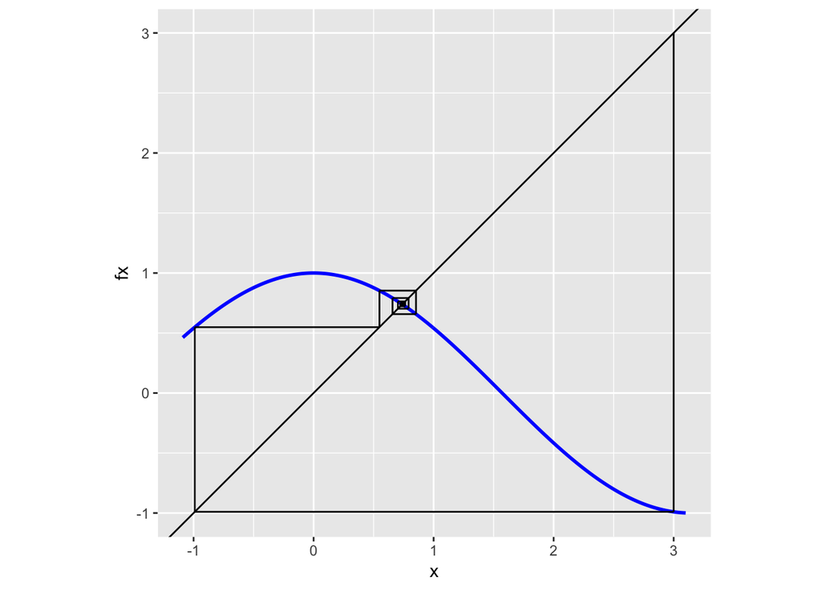

```
## [1] 0.731691
```

```r
## part a, x0 = 6
f <- function(x) cos(x)
fixedpoint_show(f, 6, iter=10)
```

```
## Starting value is: 6
## Next value of x is: 0.9601703
## Next value of x is: 0.5733805
## Next value of x is: 0.840072
## Next value of x is: 0.6674092
## Next value of x is: 0.7854279
## Next value of x is: 0.7070858
## Next value of x is: 0.7602582
## Next value of x is: 0.7246581
## Next value of x is: 0.7487261
## Next value of x is: 0.7325566
```

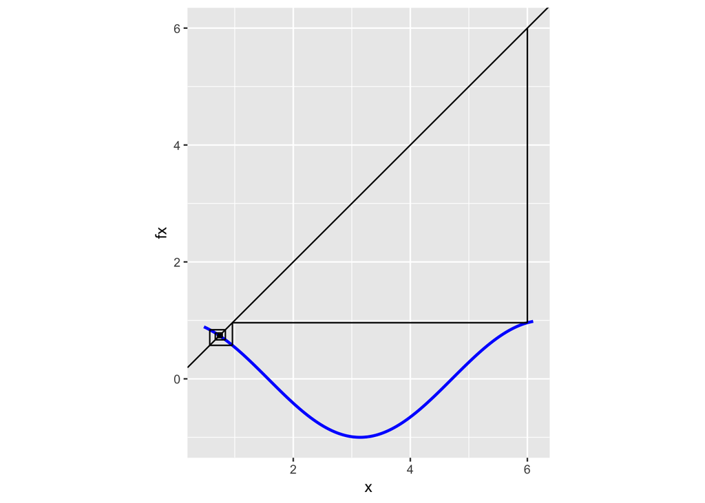

```
## [1] 0.7325566
```

```r
## part b, x0 = 2
f2 <- function(x) exp(exp(-x))
fixedpoint_show(f2, 2, iter=10)
```

```
## Starting value is: 2
## Next value of x is: 1.144921
## Next value of x is: 1.374719
## Next value of x is: 1.287768
## Next value of x is: 1.317697
## Next value of x is: 1.307022
## Next value of x is: 1.310783
## Next value of x is: 1.309452
## Next value of x is: 1.309922
## Next value of x is: 1.309756
## Next value of x is: 1.309815
```

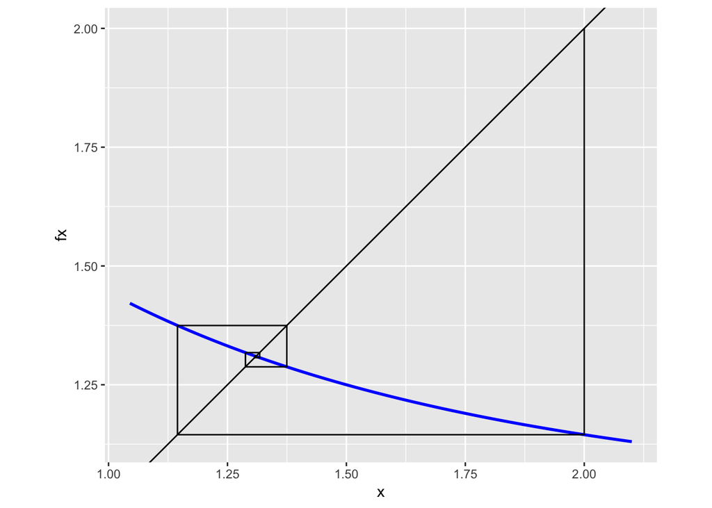

```
## [1] 1.309815
```

```r
## part c, x0 = 2
f3 <- function(x) {x - log(x) + exp(-x)}
fixedpoint_show(f3, 2, iter=10)
```

```
## Starting value is: 2
## Next value of x is: 1.442188
## Next value of x is: 1.312437
## Next value of x is: 1.309715
## Next value of x is: 1.309802
## Next value of x is: 1.309799
## Next value of x is: 1.3098
## Next value of x is: 1.3098
## Next value of x is: 1.3098
## Next value of x is: 1.3098
## Next value of x is: 1.3098
```

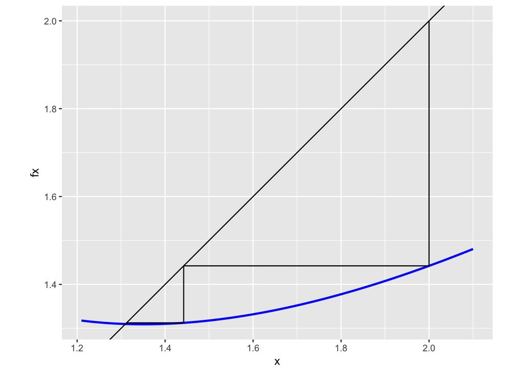

```
## [1] 1.3098
```

```r
## part d, x0 = 2 // no more than 6 iterations
f4 <- function(x) {x + log(x) - exp(-x)}
fixedpoint_show(f4, 2, iter=5)
```

```
## Starting value is: 2
## Next value of x is: 2.557812
## Next value of x is: 3.41949
## Next value of x is: 4.616252
## Next value of x is: 6.135946
## Next value of x is: 7.947946
```

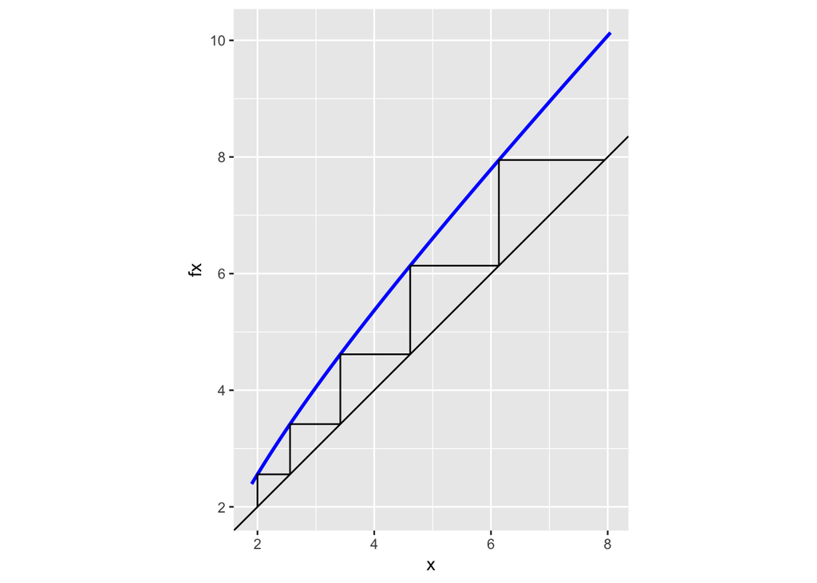

```
## [1] 7.947946
```

4. **Root Finding with Newton Raphson [22 points, 11 points for writing the code, 1 point for each graph parts a-d]**

Modified version of SPURS chapter 10, section 6, exercise 5.

For this problem, we are implementing the Newton Raphson method for root finding.

I’ve written some of the code for you. You’ll need to write the rest of the code so it can use ggplot to show the function and lines for each iteration.

You’ll probably want to refer to the code for the fixed point iteration. Also pay attention to the example used in the textbook for how the function should be programmed. The function takes a value of x and returns two values: the value of the function, and the value of the derivative at that point. Refer to section 10.3, especially page 176.

Once you have it running, produce graphs for:

- part (a) using x0 = 1, 3, 6 Results should be similar to finding fixed point of cos(x)
- part (b) using x0 = 2 Results should be similar to finding fixed point of exp(exp(-x))
- part (c) using x0 = 0
- part (d) using x0 = 1.1, 1.3, 1.4, 1.5, 1.6, 1.7 (should be simple. just repeat the command several times )

```
## Starting value is: 1
## Next x value: 0.7503639
## Next x value: 0.7391129
## Next x value: 0.7390851
## Next x value: 0.7390851
## Next x value: 0.7390851
## Next x value: 0.7390851
## Next x value: 0.7390851
## Next x value: 0.7390851
```

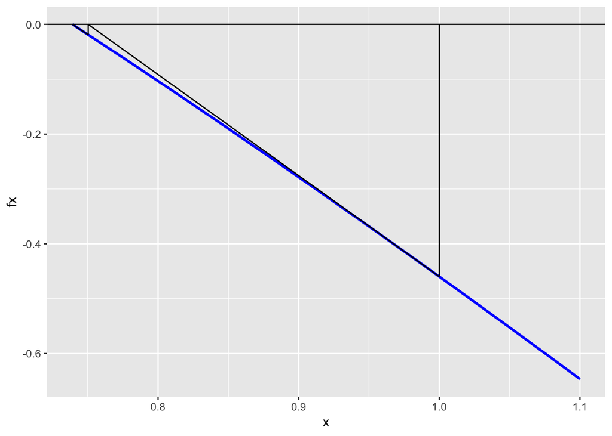

```
## [1] 0.7390851
```

```r
newtonraphson_show <- function(ftn, x0, iter = 5) {
  # applies Newton-Raphson to find x such that ftn(x)[1] == 0
  # ftn is a function of x. it returns two values, f(x) and f'(x)
  # x0 is the starting point

  # df_points is used to track each update
  df_points <- data.frame(x1=numeric(0),y1=numeric(0),x2=numeric(0),y2=numeric(0))

  xnew <- x0
  cat("Starting value is:", xnew, "\n")

  # the algorithm
  for(i in 1:iter){
    xold <- xnew
    f_xold <- ftn(xold)
    xnew <- xold - f_xold[1]/f_xold[2]
    cat("Next x value:", xnew, "\n")

    # the line segments. You will need to replace the NAs with the appropriate values
    df_points[2*i-1,] <- c(xold, 0, xold, f_xold[1]) # vertical segment
    df_points[2*i,] <- c(xold, f_xold[1], xnew, 0)   # tangent segment
  }
  x_start <- min(df_points$x1, df_points$x2, x0 - .1) # start is the min of these values
  x_end <- max(df_points$x1, df_points$x2, x0 + .1)   # end is the max of these values

  x <- seq(x_start, x_end, length.out = 200)
  fx <- rep(NA, length(x))
  for (i in seq_along(x)) {
    fx[i] <- ftn(x[i])[1]
  }
  function_data <- data.frame(x, fx)

  p <- ggplot(function_data, aes(x = x, y = fx)) + geom_line(colour = "blue", size =1) + geom_segment(aes(x = x1, y = y1, xend = x2, yend = y2), data = df_points) + geom_abline(intercept = 0, slope = 0) # write your code

  print(p)
  return(xnew)
}


## Part a
# example of how your functions could be written
fa <- function(x){
  value <- cos(x) - x   # f(x)
  derivative <- -sin(x) - 1  # f'(x)
  return(c(value, derivative))
}
newtonraphson_show(fa, 1, iter = 8)
```

```r
newtonraphson_show(fa, 3, iter = 8)
```

```
## Starting value is: 3
## Next x value: -0.4965582
## Next x value: 2.131004
## Next x value: 0.6896627
## Next x value: 0.739653
## Next x value: 0.7390852
## Next x value: 0.7390851
## Next x value: 0.7390851
## Next x value: 0.7390851
```

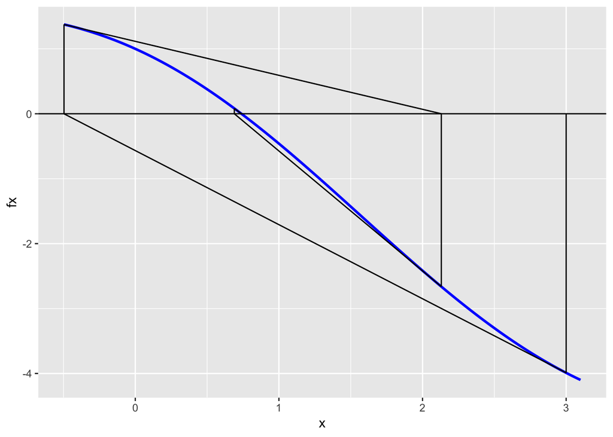

```
## [1] 0.7390851
```

```r
newtonraphson_show(fa, 6, iter = 8)
```

```
## Starting value is: 6
## Next x value: -0.9940856
## Next x value: 8.523426
## Next x value: 3.398358
## Next x value: -2.45325
## Next x value: 2.155349
## Next x value: 0.6792118
## Next x value: 0.7399276
## Next x value: 0.7390853
```

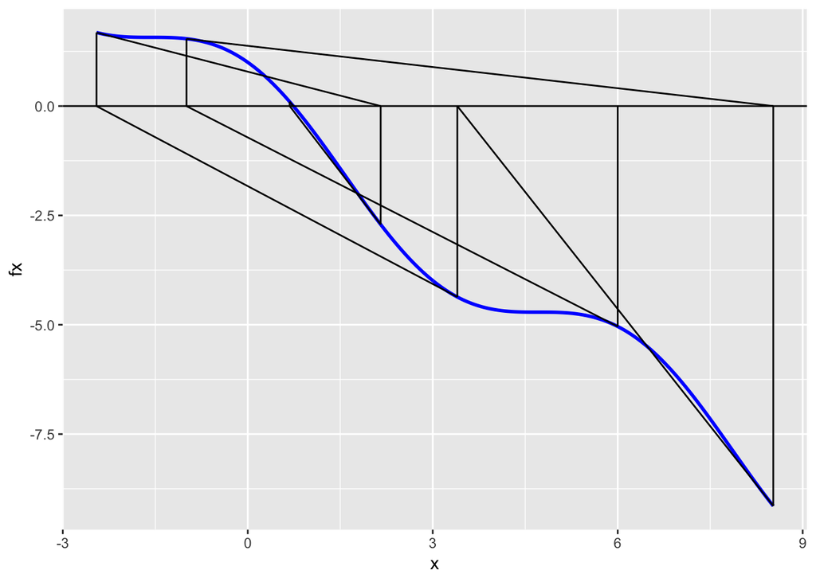

```
## [1] 0.7390853
```

```r
## Part b
fb <- function(x){
  value <- log(x) - exp(-x)
  derivative <- 1/x + exp(-x)
  return(c(value, derivative))
}
newtonraphson_show(fb, 2, iter = 8)
```

```
## Starting value is: 2
## Next x value: 1.12202
## Next x value: 1.294997
## Next x value: 1.309709
## Next x value: 1.3098
## Next x value: 1.3098
## Next x value: 1.3098
## Next x value: 1.3098
## Next x value: 1.3098
```

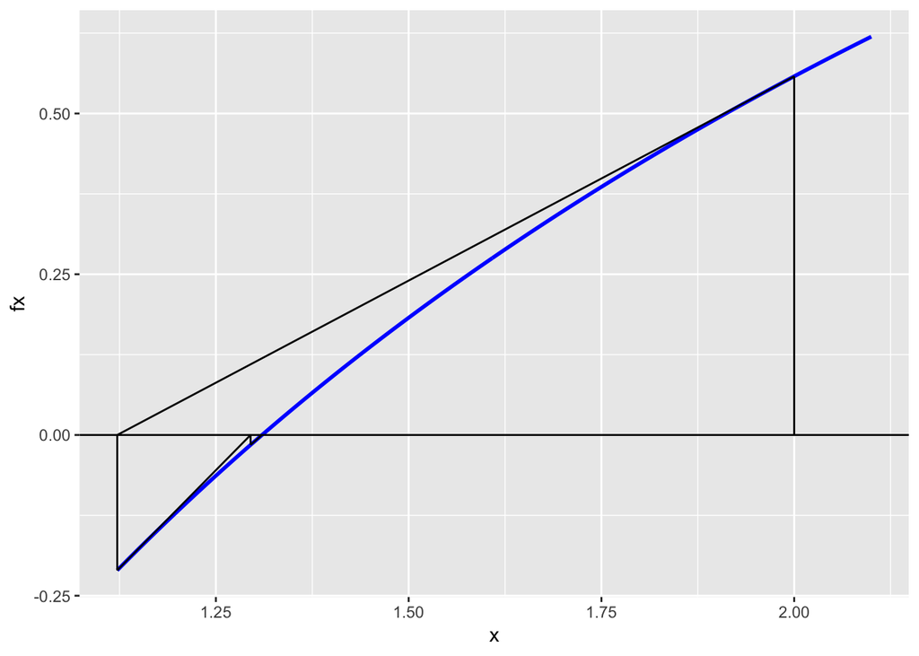

```
## [1] 1.3098
```

```r
## Part c
fc <- function(x){
  value <- (x^3 - x - 3)
  derivative <- (3*x^2 - 1)
  return(c(value, derivative))
}
newtonraphson_show(fc, 0, iter = 8)
```

```
## Starting value is: 0
## Next x value: -3
## Next x value: -1.961538
## Next x value: -1.147176
## Next x value: -0.006579371
## Next x value: -3.000389
## Next x value: -1.961818
## Next x value: -1.14743
## Next x value: -0.007256248
```

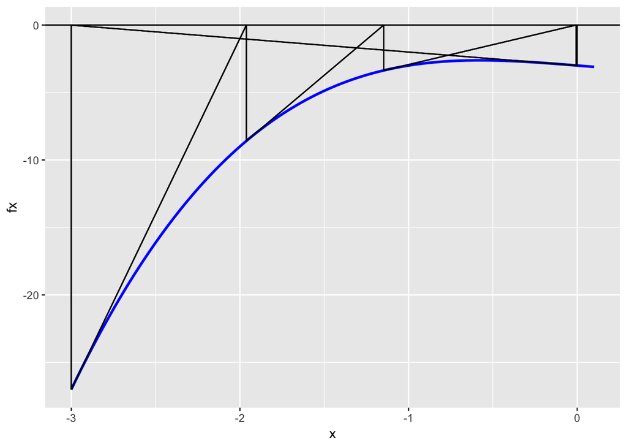

```
## [1] -0.007256248
```

```r
## Part d
fd <- function(x){
  value <- (x^3 - 7*x^2 + 14*x - 8)
  derivative <- (3*x^2 - 14*x + 14)
  return(c(value, derivative))
}
newtonraphson_show(fd, 1.1, iter = 8)
```

```
## Starting value is: 1.1
## Next x value: 0.9829596
## Next x value: 0.9996266
## Next x value: 0.9999998
## Next x value: 1
## Next x value: 1
## Next x value: 1
## Next x value: 1
## Next x value: 1
```

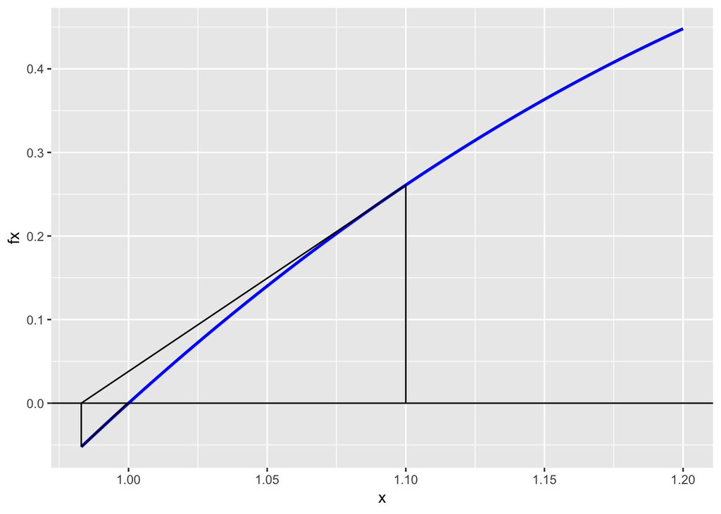

```
## [1] 1
```

```r
newtonraphson_show(fd, 1.3, iter = 8)
```

```
## Starting value is: 1.3
## Next x value: 0.6482759
## Next x value: 0.9059224
## Next x value: 0.9901916
## Next x value: 0.9998744
## Next x value: 1
## Next x value: 1
## Next x value: 1
## Next x value: 1
```

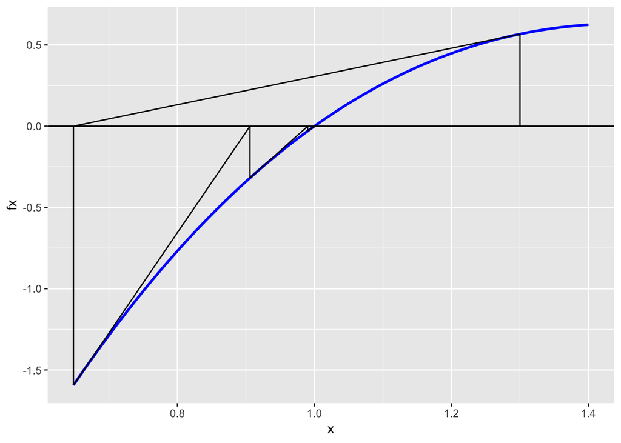

```
## [1] 1
```

```r
newtonraphson_show(fd, 1.4, iter = 8)
```

```
## Starting value is: 1.4
## Next x value: -0.8285714
## Next x value: 0.07435419
## Next x value: 0.6136214
## Next x value: 0.891034
## Next x value: 0.9871826
## Next x value: 0.9997869
## Next x value: 0.9999999
## Next x value: 1
```

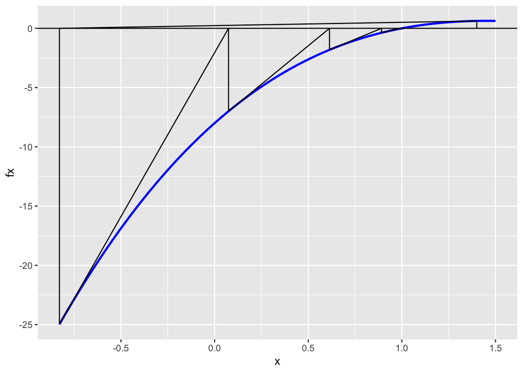

```
## [1] 1
```

```r
newtonraphson_show(fd, 1.5, iter = 8)
```

```
## Starting value is: 1.5
## Next x value: 4
## Next x value: 4
## Next x value: 4
## Next x value: 4
## Next x value: 4
## Next x value: 4
## Next x value: 4
## Next x value: 4
```

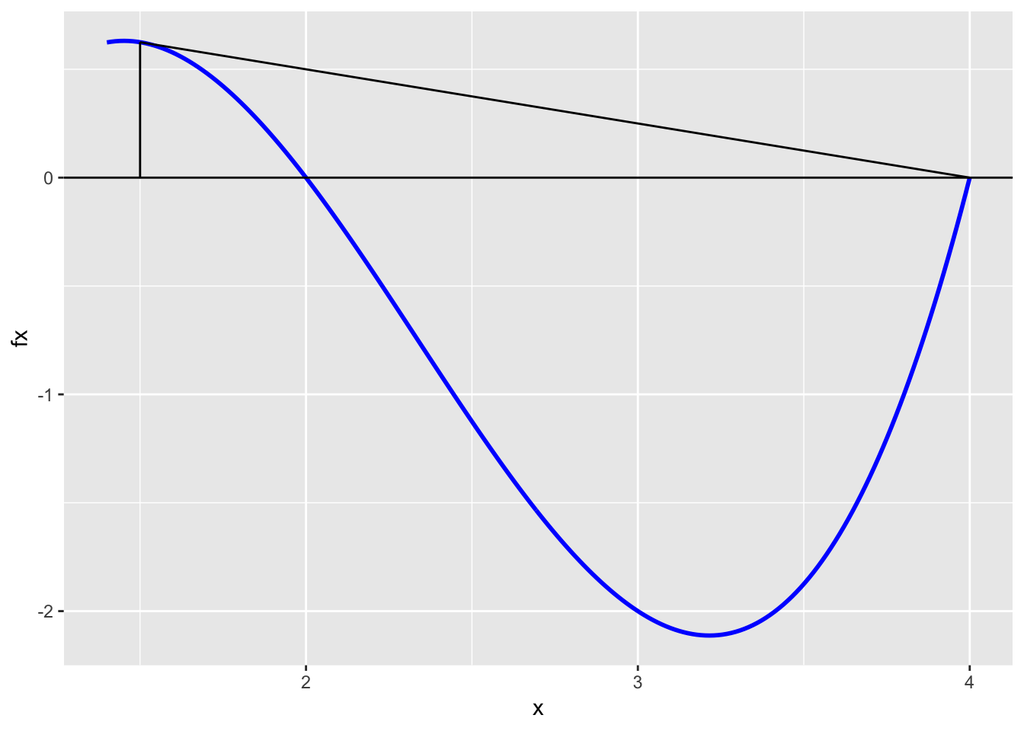

```
## [1] 4
```

```r
newtonraphson_show(fd, 1.6, iter = 8)
```

```
## Starting value is: 1.6
## Next x value: 2.4
## Next x value: 2.013793
## Next x value: 2.000091
## Next x value: 2
## Next x value: 2
## Next x value: 2
## Next x value: 2
## Next x value: 2
```

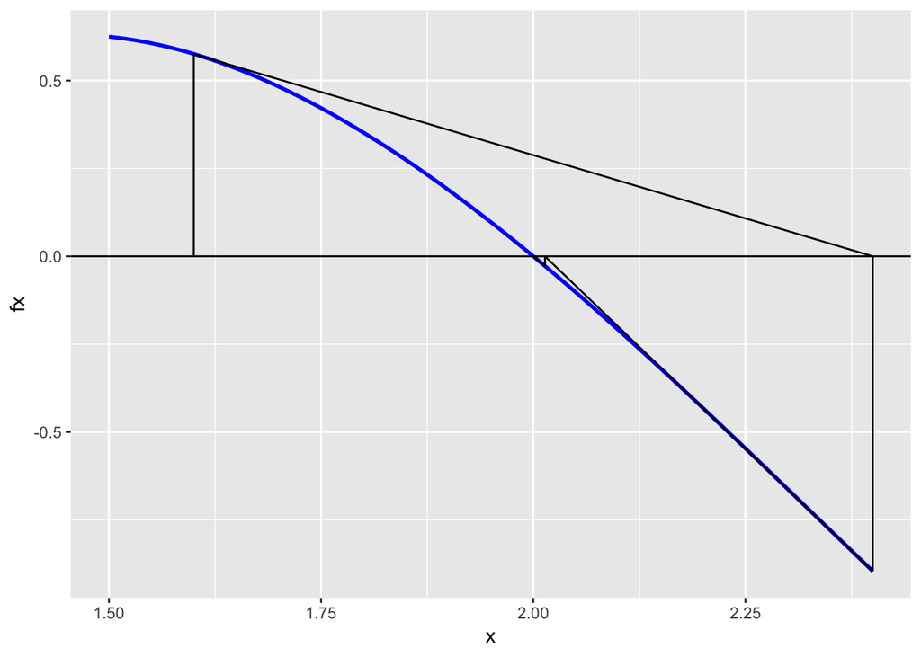

```
## [1] 2
```

```r
newtonraphson_show(fd, 1.7, iter = 8)
```

```
## Starting value is: 1.7
## Next x value: 2.127434
## Next x value: 2.005485
## Next x value: 2.000015
## Next x value: 2
## Next x value: 2
## Next x value: 2
## Next x value: 2
## Next x value: 2
```

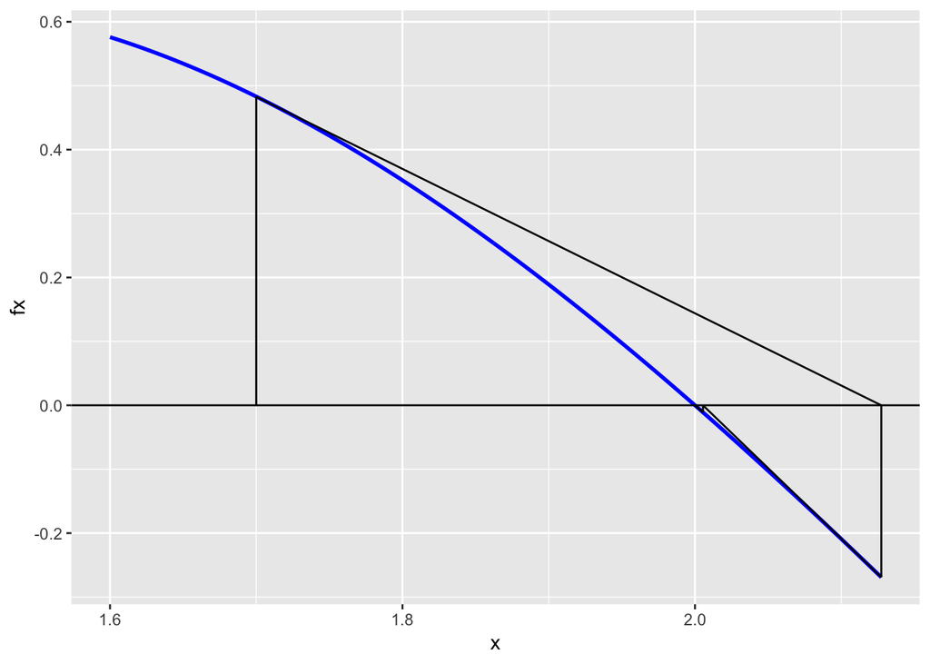

```
## [1] 2
```

5. **Root Finding with Secant Method [26 points- 20 points for completing the code. 2 pts each graph]**

Modified version of SPURS chapter 10, section 6, exercise 6.

Implement the secant method for root finding. Write a function called `secant_show` similar to the `newtonraphson_show` and `fixedpoint_show` functions. In your function, perform iterations of the algorithm and plot the results. It should behave in a very similar fashion to `newtonraphson_show`.

A framework of the function has been provided. It will take 4 inputs:

- The function. It takes a value of x and returns the value of f(x). (no need to return the derivative)
- x0 The x-value at iteration 0
- x1 The x-value at iteration 1. The secant uses the last two values, and draws a secant line that connects those until that secant line intersects the x-axis.
- the number of iterations to perform

While non-trivial, I do believe that the previous examples will provide a good guide for writing your code.

When drawing the secant line, keep in mind that what will be your start and end point can be different depending on where xnew will be. (For example, xnew can be to the left of x0 and x1, it can be between x0 and x1, and it can be to the right of x0 and x1.) In each case, the starting point of the line segment should be the left-most point, and the end-point of the line segment should be the right-most point. You cannot assume that xnew will always be one of the endpoints.

- Use your function to find the roots of $cos(x) - x$ using $x_0 = 1$ and $x_1 = 2$.
- Use your function to find the root of $log(x) - exp(-x)$ using $x_0 = 1$ and $x_1 = 2$.
- Find the root of $x^2 - 0.5$ using $x_0 = 4$ and $x_1 = 3.5$.

```
## Starting value is: 1 and 2
## Next x value: 0.7650347
## Next x value: 0.7422994
## Next x value: 0.7391033
## Next x value: 0.7390851
## Next x value: 0.7390851
```

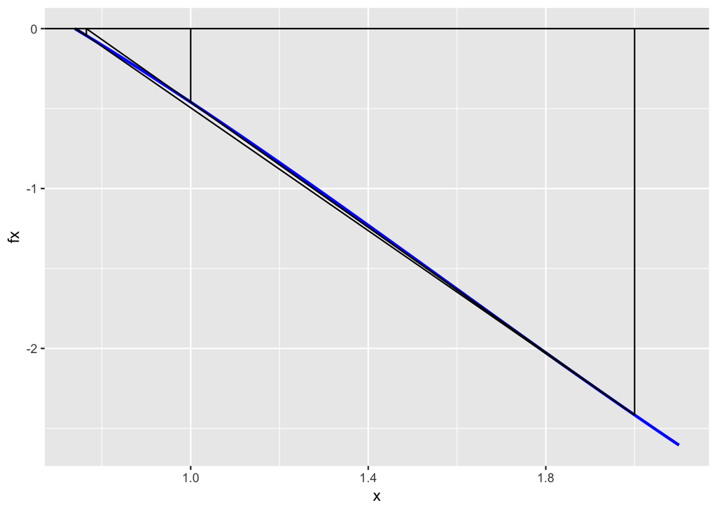

```
## [1] 0.7390851
```

```r
secant_show <- function(ftn, x0, x1, iter = 5) {
df_points <- data.frame(x_1=numeric(0),y_1=numeric(0),x_2=numeric(0),y_2=numeric(0))

  xolder<-x0
  xold<-x1
  cat("Starting value is:", xolder, "and" ,xold, "\n")

  df_points[1,]<-c(xolder,0,xolder,ftn(xolder))

  # the algorithm
  for(i in 1:iter){
    xnew <- xold - ftn(xold)*(xold-xolder)/(ftn(xold)-ftn(xolder))
    cat("Next x value:", xnew, "\n")

    # the line segments. You will need to replace the NAs with the appropriate values
    df_points[3*i-1,] <- c(xolder, ftn(xolder), xold, ftn(xold))      # vertical segment
    df_points[3*i,] <- c(xold, 0, xold, ftn(xold))                  # vertical segment
    df_points[3*i+1,] <- c(xold, ftn(xold), xnew, 0)                    # tangent segment

    xolder<-xold
    xold<-xnew
  }

   ### use ggplot to plot the function and the segments for each iteration
  # determine the limits to use
  x_start <- min(df_points$x_1, df_points$x_2, x0 - .1, x1 - .1) # start is the min of these values
  x_end <- max(df_points$x_1, df_points$x_2, x0 + .1, x1 + .1)   # end is the max of these values

  x <- seq(x_start, x_end, length.out = 200)
  fx <- rep(NA, length(x))
  for (i in seq_along(x)) {
    fx[i] <- ftn(x[i])
  }
  function_data <- data.frame(x, fx)

  p <- ggplot(function_data, aes(x = x, y = fx)) + geom_line(colour = "blue", size=1) +  # plot the function
    geom_segment(aes(x = x_1, y = y_1, xend = x_2, yend = y_2), data = df_points) + # plot the segments, we specify that a different data frame is used here
    geom_abline(intercept = 0, slope = 0) # plot the line y = 0

  print(p) # produce the plot
  return(xnew)
}
g1<-function(x) cos(x) - x
secant_show(g1,1,2,5)
```

```r
g2<-function(x) log(x) - exp(-x)
secant_show(g2,1,2,5)
```

```
## Starting value is: 1 and 2
## Next x value: 1.39741
## Next x value: 1.285476
## Next x value: 1.310677
## Next x value: 1.309808
## Next x value: 1.3098
```

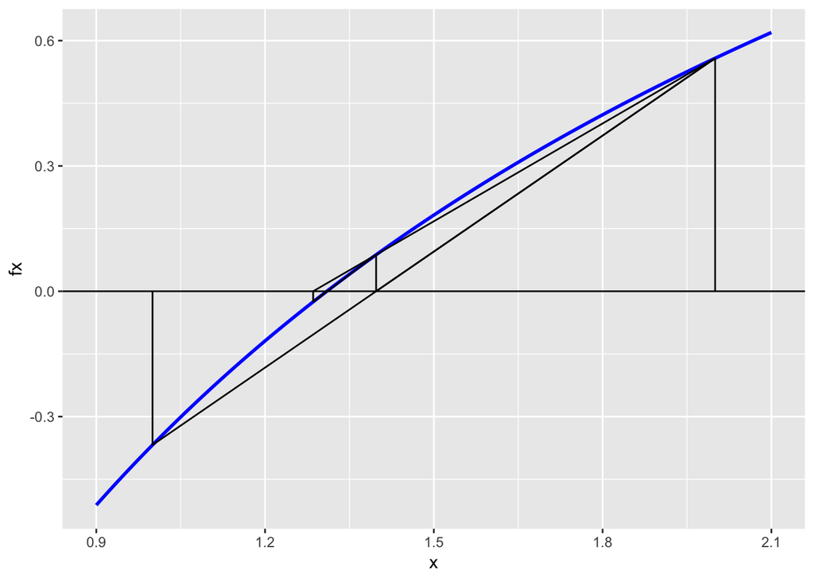

```
## [1] 1.3098
```

```r
g3<-function(x) x^2 - 0.5
secant_show(g3,4,3.5,6)
```

```
## Starting value is: 4 and 3.5
## Next x value: 1.933333
## Next x value: 1.337423
## Next x value: 0.9434163
## Next x value: 0.7724116
## Next x value: 0.7161008
## Next x value: 0.7075014
```

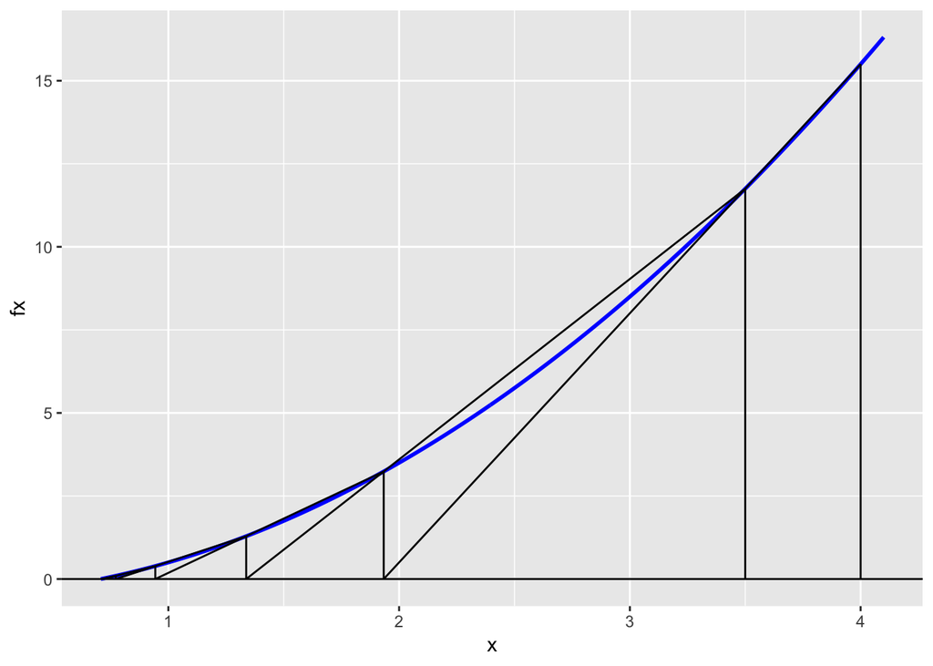

```
## [1] 0.7075014
```

6. **Coordinate Descent Algorithm for Optimization [20 points]**

Coordinate descent is an optimization algorithm. The algorithm attempts to find a local minimum of a function. We perform a search in one direction to find the value that minimizes the function in that direction while the other values are held constant. Once the value for that direction is updated, you perform the same operation for the other coordinate directions. This repeats until it has been updated for all coordinate directions, at which point the cycle repeats.

Thus for a function of two variables $f(x,y)$, a simple version of the algorithm can be described as follows:

1. Start with some initial values of $x$ and $y$. This is time 0, so we have $x^{(0)}$ and $y^{(0)}$.
2. Iterate:
   1. Update $x^{(t+1)}$ to be the value of $x$ that minimizes $f(x,y = y^{(t)})$
   2. Update $y^{(t+1)}$ to be the value of $y$ that minimizes $f(x = x^{(t+1)},y)$
3. Stop when some convergence criterion has been met.

The “tricky” part of the algorithm is finding the value that minimizes the function along one of the directions.

**Golden Section Search Method (with Video)** This unidimensional minimization be done in one of many ways, but for our purposes, we will use the golden section search method.

The premise of how the golden section search works is summarized very nicely in this video from CUBoulderComputing: https://vimeo.com/86277921

I will provide the code for the golden section search method here. This is a modified version of Eric Cai’s code (https://chemicalstatistician.wordpress.com). It has been modified so that the locations of x1 and x2 match the CUBoulderComputing video

```r
##### A modifcation of code provided by Eric Cai
##### A modifcation of code provided by Eric Cai
golden = function(f, lower, upper, tolerance = 1e-5)
{
   golden.ratio = 2/(sqrt(5) + 1)

   ## Use the golden ratio to find the initial test points
   x1 <- lower + golden.ratio * (upper - lower)
   x2 <- upper - golden.ratio * (upper - lower)

   ## the arrangement of points is:
   ## lower ----- x2 --- x1 ----- upper

   ### Evaluate the function at the test points
   f1 <- f(x1)
   f2 <- f(x2)

   while (abs(upper - lower) > tolerance) {
        if (f2 > f1) {
        # the minimum is to the right of x2
        lower <- x2  # x2 becomes the new lower bound
        x2 <- x1     # x1 becomes the new x2
        f2 <- f1     # f(x1) now becomes f(x2)
        x1 <- lower + golden.ratio * (upper - lower)
        f1 <- f(x1)  # calculate new x1 and f(x1)
        } else {
        # then the minimum is to the left of x1
        upper <- x1  # x1 becomes the new upper bound
        x1 <- x2     # x2 becomes the new x1
        f1 <- f2
        x2 <- upper - golden.ratio * (upper - lower)
        f2 <- f(x2)  # calculate new x2 and f(x2)
        }
    }
    (lower + upper)/2 # the returned value is the midpoint of the bounds
}
```

We can thus use the golden search to find the minimizing value of a function. For example, the function $f(x) = (x - 3)^2$ has a minimum value at $x = 3$.

```r
f <- function(x){ (x - 3)^2 }
golden(f, 0, 10)
```

```
## [1] 3.000001
```

**Back to Coordinate Descent**

With our golden search function, we can now create our coordinate descent algorithm:

1. Start with some initial values of $x$ and $y$. This is time 0, so we have $x^{(0)}$ and $y^{(0)}$.
2. Iterate:
   1. Update $x$:
      1. Find the function $f(x) = f(x,y = y^{(t)})$
      2. Use golden search to minimize $f(x)$
      3. Set $x^{(t+1)}$ be the result of the search.
   2. Update $y$
      1. Find the function $f(y) = f(x = x^{(t+1)},y)$
      2. Use golden search to minimize $f(y)$
      3. Set $y^{(t+1)}$ be the result of the search.
3. Stop when some convergence criterion has been met.

**Write code to perform coordinate descent to minimize the following function:**

$$g(x,y) = 5 x ^ 2 - 6 x y + 5 y ^ 2$$

```r
g <- function(x,y) {
    5 * x ^ 2 - 6 * x * y + 5 * y ^ 2
}
x <- seq(-1.5,1, len=100)
y <- seq(-1.5,1, len=100)
```

Requirements for this task:

1. Your search space for the golden search can be limited to the range -1.5 to 1.5 for both the x and y directions.
2. For your starting point, use x = -1.5, and y = -1.5.
3. For the first step, hold y constant, and find the minimum in the x direction.
4. Plot the segments showing each ‘step’ of the algorithm onto the contour plot.
5. After each full iteration, print out the current values of x and y. Hint: after your first full iteration, the next location should be (-0.9, -0.54).
6. Stop after 15 full iterations, or if the difference between one x and the next is less then `1e-5`. The true minimum is at (0,0). Your code should come close to that.

My complete solution is 12 lines. Of course yours might be longer, but that should give you an idea of how complicated it needs to be.

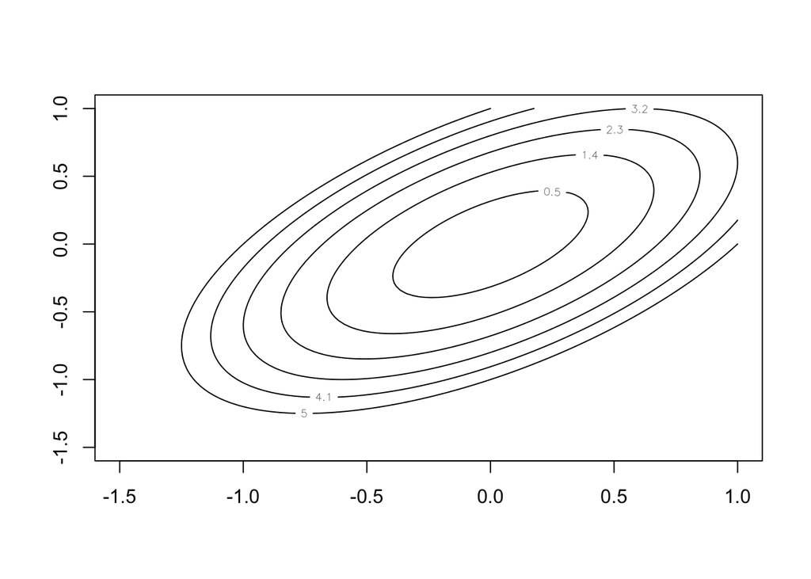

```r
# two options to plot. Which one to use is your choice. You do not need to do both.
# remember, ggplot requires data to be in tidy form

# use ggplot
#df <- data.frame(x = rep(x, each = 100), y = rep(y, 100), z = outer(x,y,g)[1:100^2])
#ggplot(df, aes(x=x,y=y,z=z)) + geom_contour(binwidth = 0.9, boundary = 0.5)

# or use contour
# contour uses a large matrix to store values of the plot
z <- outer(x,y,g)
contour(x,y,z, levels = seq(.5,5,by=.9)) # code to plot contour lines
```

```r
# write your code here
x_i <- -1.5
y_i <- -1.5
x_result<-c(x_i)
y_result<-c(y_i)
i<-1
df_points <- data.frame(x_1=numeric(0),y_1=numeric(0),x_2=numeric(0),y_2=numeric(0))
#cat("Starting value is: (", x_i, "," ,y_i, ")\n")


while(i<=15){
  x_now <- x_result[i]
  y_now <- y_result[i]

  fx<-function(x)  5 * x ^ 2 - 6 * x * y_now + 5 * y_now ^ 2

  x_next<-golden(fx,-1.5,1.5,1e-5)

  df_points[2*i-1, ]<-c(x_now,y_now,x_next,y_now)
  fy<-function(y)  5 * x_next ^ 2 - 6 * x_next * y + 5 * y ^ 2

  y_next<-golden(fy,-1.5,1.5,1e-5)

  df_points[2*i, ]<-c(x_next,y_now,x_next,y_next)

i<-i+1
  x_result[i]<-x_next
  y_result[i]<-y_next
  cat( x_result[i-1], "," ,y_result[i-1], "\n")

  if(abs(x_now-x_next) < 1e-5)
  {
    break
  }

  }
```

```
## -1.5 , -1.5
## -0.9000005 , -0.5399991
## -0.3239996 , -0.1943994
## -0.1166404 , -0.06998455
## -0.04199138 , -0.02519619
## -0.01511759 , -0.009071722
## -0.005444077 , -0.003266769
## -0.001961105 , -0.001174652
## -0.0007038706 , -0.0004213549
## -0.0002519686 , -0.0001515037
## -8.941291e-05 , -5.364775e-05
## -3.315613e-05 , -1.788258e-05
## -1.105204e-05 , -6.830539e-06
```

```r
cat("Final result is: (", x_result[i], "," ,y_result[i], ")\n")
```

```
## Final result is: ( -4.221505e-06 , -4.221505e-06 )
```

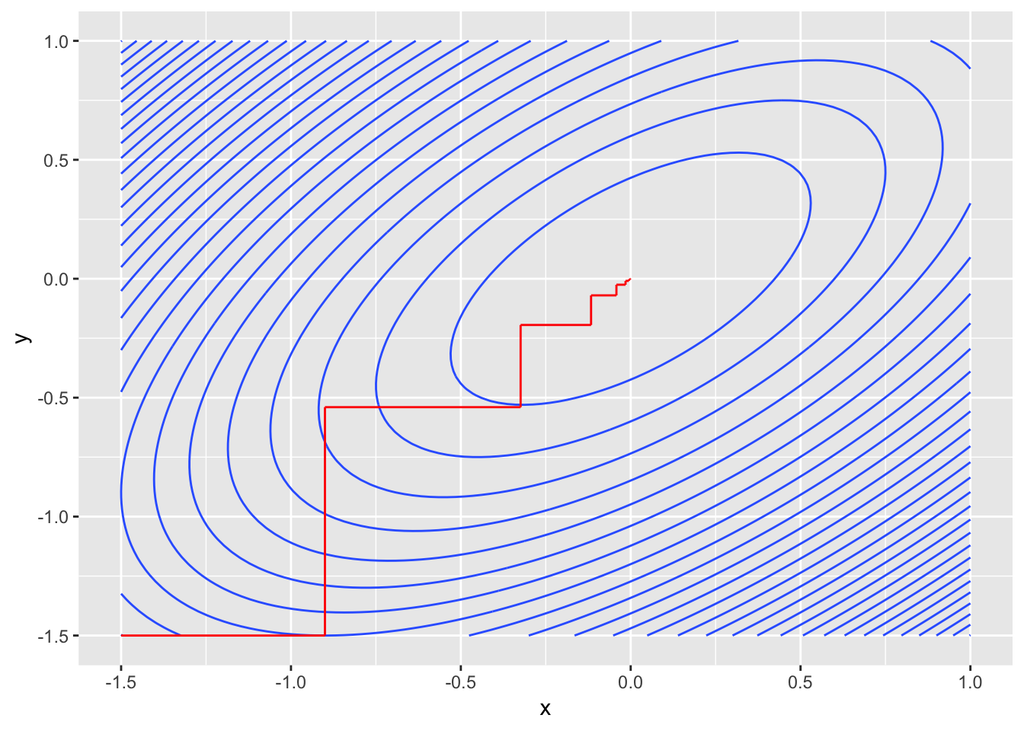

```r
df <- data.frame(x = rep(x, each = 100), y = rep(y, 100), z = outer(x,y,g)[1:100^2])
ggplot() + geom_contour(data = df, aes(x=x,y=y,z=z), binwidth = 0.9, boundary = 0.5) + geom_segment(aes(x = x_1, y = y_1, xend = x_2, yend = y_2), data = df_points, color = "red")
```